# Risk Factor Analysis

## Outcome Variable

**Outcome Variable:** whz

## Predictor Variables

**Intervention Variable:** mwtkg

**Adjustment Set:**

- arm
- W_mage
- W_fage
- meducyrs
- feducyrs
- single
- brthmon
- delta_W_mage
- delta_W_fage
- delta_meducyrs
- delta_feducyrs
- delta_single
- delta_brthmon

## Stratifying Variables

The analysis was stratified on these variable(s):

- agecat

## Data Summary

| agecat | mwtkg | n_cell | n |
| --- | --- | --- | --- |
| Birth | >=58 kg | 16274 | 25587 |
| Birth | <52 kg | 3938 | 25587 |
| Birth | [52-58) kg | 5375 | 25587 |
| 6 months | >=58 kg | 16400 | 28654 |
| 6 months | <52 kg | 6377 | 28654 |
| 6 months | [52-58) kg | 5877 | 28654 |
| 24 months | >=58 kg | 4097 | 7932 |
| 24 months | <52 kg | 2296 | 7932 |
| 24 months | [52-58) kg | 1539 | 7932 |

The following strata were considered:

- agecat: 24 months
- agecat: 6 months
- agecat: Birth

## Methods Detail

We’re interested in the causal parameters $E[Y_a]$ for all values of $a \in \mathcal{A}$. These parameters represent the mean outcome if, possibly contrary to fact, we intervened to set all units to have $A=a$. Under the randomization and positivity assumptions, these are identified by the statistical parameters $\psi_a=E_W[E_{Y|A,W}(Y|A=a,W)]$. In addition, we’re interested in the mean of $Y$, $E[Y]$ under no intervention (the observed mean). We will estimate these parameters by using SuperLearner to fit the relevant likelihood factors – $E_{Y|A,W}(Y|A=a,W)$ and $p(A=a|W)$, and then updating our likelihood fit using a joint TMLE.

For unadjusted analyses ($W=\{\}$), initial likelihoods were estimated using Lrnr_glm to estimate the simple $E(Y|A)$ and Lrnr_mean to estimate $p(A)$. For adjusted analyses, a small library containing Lrnr_glmnet, Lrnr_xgboost, and Lrnr_mean was used.

Having estimated these parameters, we will then use the delta method to estimate relative risks and attributable risks relative to a prespecified baseline level of $A$.

# Results Detail

## Results Plots

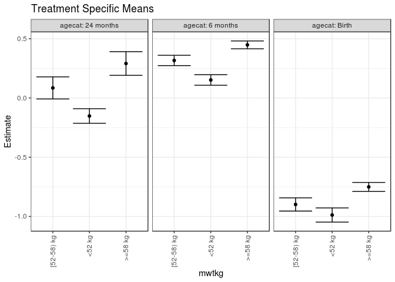

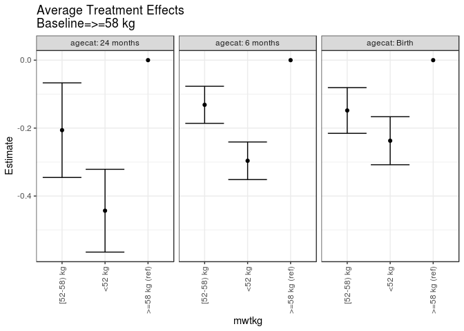

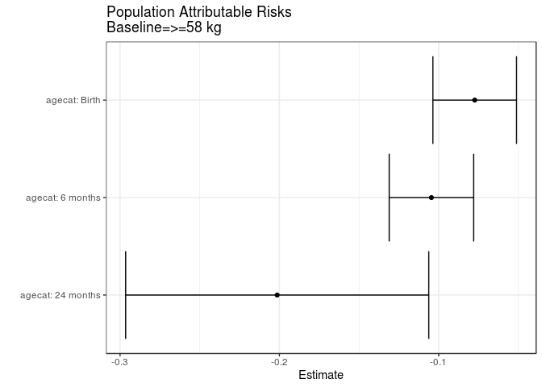

## Results Table

### Parameter: TSM

| agecat | intervention_level | baseline_level | estimate | ci_lower | ci_upper |
| --- | --- | --- | --- | --- | --- |
| Birth | >=58 kg | NA | -0.7507140 | -0.7882502 | -0.7131778 |
| Birth | <52 kg | NA | -0.9878816 | -1.0477660 | -0.9279973 |
| Birth | [52-58) kg | NA | -0.8988442 | -0.9546471 | -0.8430414 |
| 6 months | >=58 kg | NA | 0.4482710 | 0.4152015 | 0.4813404 |
| 6 months | <52 kg | NA | 0.1520917 | 0.1076003 | 0.1965830 |
| 6 months | [52-58) kg | NA | 0.3167996 | 0.2732686 | 0.3603306 |
| 24 months | >=58 kg | NA | 0.2910131 | 0.1910525 | 0.3909738 |
| 24 months | <52 kg | NA | -0.1520828 | -0.2136064 | -0.0905591 |
| 24 months | [52-58) kg | NA | 0.0849601 | -0.0082805 | 0.1782008 |

### Parameter: E(Y)

| agecat | intervention_level | baseline_level | estimate | ci_lower | ci_upper |
| --- | --- | --- | --- | --- | --- |
| Birth | NA | NA | -0.8281276 | -0.8546518 | -0.8016033 |
| 6 months | NA | NA | 0.3436838 | 0.3237316 | 0.3636360 |
| 24 months | NA | NA | 0.0896330 | 0.0536411 | 0.1256249 |

### Parameter: ATE

| agecat | intervention_level | baseline_level | estimate | ci_lower | ci_upper |
| --- | --- | --- | --- | --- | --- |
| Birth | >=58 kg | >=58 kg | 0.0000000 | 0.0000000 | 0.0000000 |
| Birth | <52 kg | >=58 kg | -0.2371676 | -0.3078567 | -0.1664786 |
| Birth | [52-58) kg | >=58 kg | -0.1481302 | -0.2153759 | -0.0808846 |
| 6 months | >=58 kg | >=58 kg | 0.0000000 | 0.0000000 | 0.0000000 |
| 6 months | <52 kg | >=58 kg | -0.2961793 | -0.3514990 | -0.2408596 |
| 6 months | [52-58) kg | >=58 kg | -0.1314714 | -0.1860373 | -0.0769054 |
| 24 months | >=58 kg | >=58 kg | 0.0000000 | 0.0000000 | 0.0000000 |
| 24 months | <52 kg | >=58 kg | -0.4430959 | -0.5649233 | -0.3212685 |
| 24 months | [52-58) kg | >=58 kg | -0.2060530 | -0.3452703 | -0.0668357 |

### Parameter: PAR

| agecat | intervention_level | baseline_level | estimate | ci_lower | ci_upper |
| --- | --- | --- | --- | --- | --- |
| Birth | >=58 kg | NA | -0.0774136 | -0.1036614 | -0.0511657 |
| 6 months | >=58 kg | NA | -0.1045872 | -0.1311013 | -0.0780730 |
| 24 months | >=58 kg | NA | -0.2013801 | -0.2965008 | -0.1062594 |